# PDX: Mouse vs. Combined

Alistair Martin

21 March, 2019

# Load libraries and data

```r
root.dir <- "~/OneDrive/projects/"
source(paste0(root.dir,"R.utils/RNASEQ.utils.R"))

project.dir <- paste0(root.dir,"PDX/")
source(paste0(project.dir,"src/load.PDX.R"))

load.counts <- function(fname){
  counts <- fread(fname)
  gene.list <- counts[,Geneid]
  #gene.info <- counts[,1:6]
  counts <- as.matrix(counts[,-(1:6)])
  rownames(counts) <- gene.list
  return(list(
    "mouse"=counts[substr(rownames(counts),1,4)=="ENSM",,drop=F],
    "human"=counts[substr(rownames(counts),1,4)=="ENSG",,drop=F]
  ))
}

data.dir <- paste0(project.dir,"data/mouse.vs.comb/")
dnames <- list.dirs(data.dir,recursive = F)
dnames <- dnames[!grepl("_archive",dnames)]
x <- lapply(dnames,function(dname){
  x <- lapply(list.files(dname,full.names = T,include.dirs = F),load.counts)
  x <- list(
    do.call("cbind",lapply(x,"[[","mouse")),
    do.call("cbind",lapply(x,"[[","human"))
  )
  for(i in 1:2) colnames(x[[i]]) <- paste0(basename(dname),".",colnames(x[[i]]))
  return(x)
})

rnaseq <- list()
rnaseq$count <- do.call("cbind",lapply(x,"[[",1))
rnaseq$meta <- data.table(
  sname=colnames(rnaseq$count),
  genome=rep(sapply(dnames,basename),each=3),
  sample.ID=rep(c("R1","R2","R3"),length(x)),
  library.size=colSums(rnaseq$count)/1E6
)
```

Below we test for differences when one aligns mouse cell line rnaseq data against the combined (human + mouse) genome compared to the mouse genome alone. The below table indicates our experimental blanches/replicates:

```r
rnaseq$meta
```

```
##                     sname    genome sample.ID library.size
## 1: b37.mmu10.Uni_0_100_R1 b37.mmu10        R1     18.49010
## 2: b37.mmu10.Uni_0_100_R2 b37.mmu10        R2     17.91263
## 3: b37.mmu10.Uni_0_100_R3 b37.mmu10        R3     21.01728
## 4:     mmu10.Uni_0_100_R1     mmu10        R1     18.60453
## 5:     mmu10.Uni_0_100_R2     mmu10        R2     18.00606
## 6:     mmu10.Uni_0_100_R3     mmu10        R3     21.13733
## 7: mmu10.b37.Uni_0_100_R1 mmu10.b37        R1     18.49009
## 8: mmu10.b37.Uni_0_100_R2 mmu10.b37        R2     17.91262
## 9: mmu10.b37.Uni_0_100_R3 mmu10.b37        R3     21.01726
```

# PCA Analysis

In the below PCA plots we find that:

- PC1 and PC2 accounts for 98% of the variance
- Using PC1 and PC2 you can distinguish between the replicates
- However, PC3 allows one to distinguish between the alignment using mouse only and combined.

Please note that the PCA is calculated using the 1000 most variable genes. Since we expect more variation between the biological replicates, rather than the pipeline variants, this subsetting will be driven by the former.

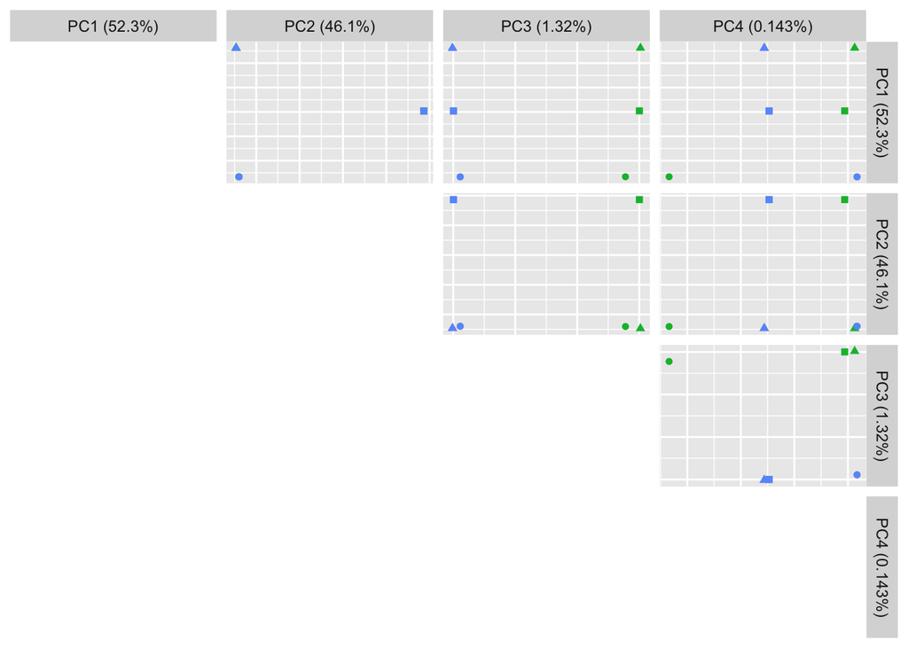

```r
x <- cbind(pca.run(rnaseq$count,rename = T),rnaseq$meta)
ggpairs(x,columns = 1:4,
        mapping = aes(color=factor(genome),shape=factor(sample.ID)),
        progress = F,
        lower  = list(continuous = "blank"),
        upper  = list(continuous = "points"),
        diag  = list(continuous = "blankDiag"))
```

PC3 is composed of contributions from the 1000 subsetted genes. The below plots show the percentage contributions of these genes w.r.t each of the principal components. We find that PC3 is dominated by a variation in a small set of genes, unlike PC1 and PC2, which vary instead across all genes.

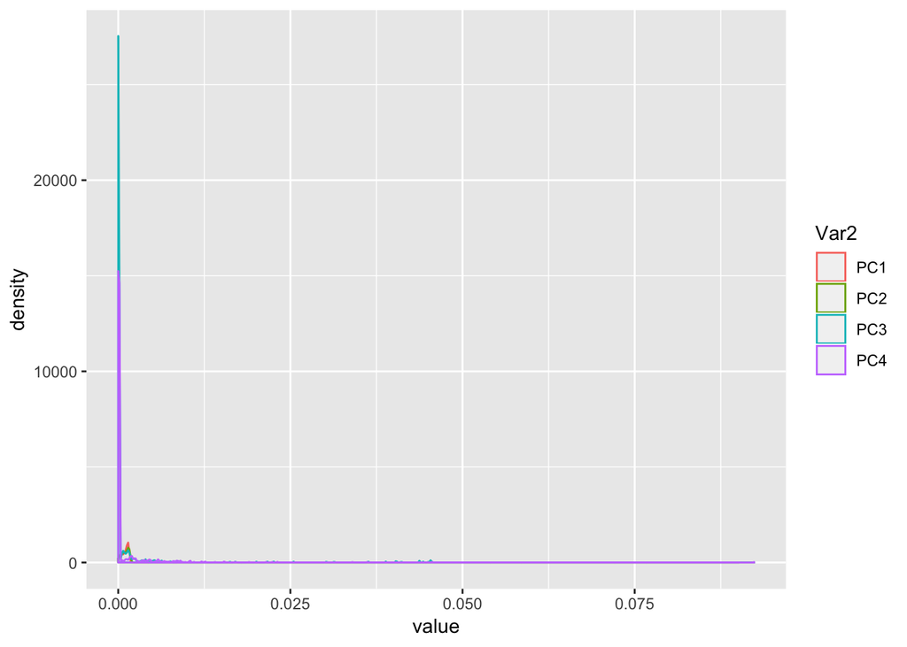

```r
x <- pca.prep(rnaseq$count,T,1000)
x <- prcomp(t(x),scale=T)
x <- abs(x$rotation)
x <- sweep(x,2,colSums(x),"/")
csx <- apply(x, 2, function(y) cumsum(sort(y,dec=T)))

ggplot(melt(x[,1:4])) + aes(x=value,colour=Var2) + geom_density()
```

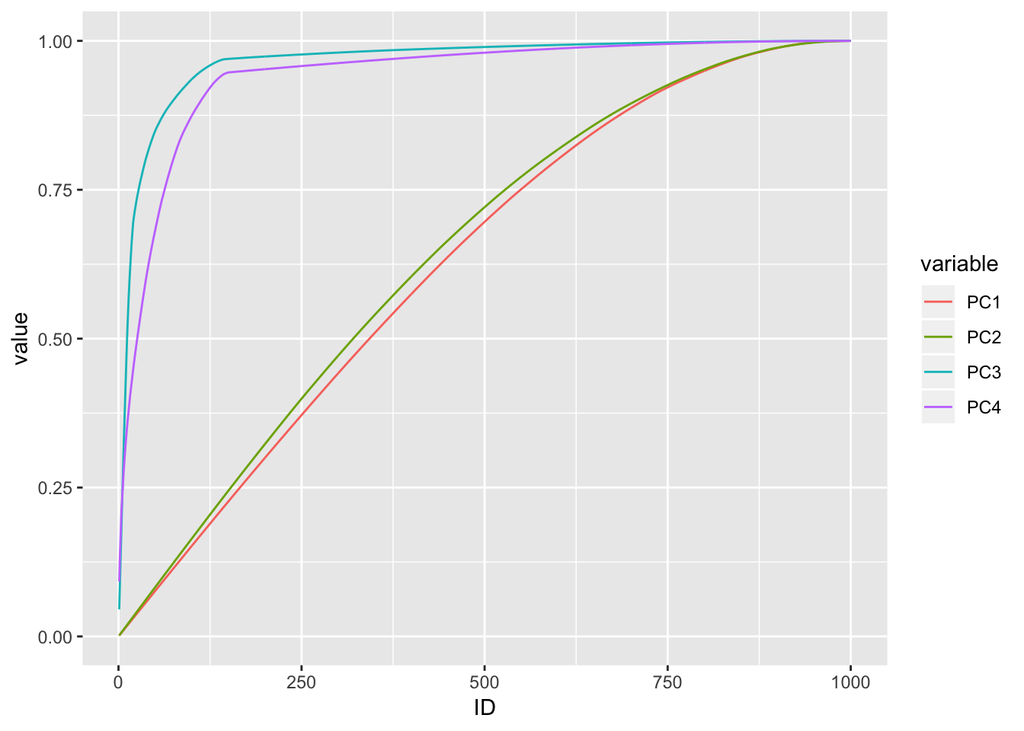

```r
ggplot(melt(data.frame(cbind(ID=1:nrow(x),csx[,1:4])),id.vars="ID")) + aes(x=ID,y=value,color=variable) + geom_line()
```

The below list gives all genes which contribute at least 1% to PC3

```r
top.genes <- x[which(x[,3]>0.01),3,drop=F]
if(nrow(top.genes)){
  top.genes <- data.table(top.genes,keep.rownames = "ENSEMBL")
  print(top.genes <- merge(
    top.genes,
    biomaRt::select(org.Mm.eg.db,keys=top.genes$ENSEMBL,keytype = "ENSEMBL",columns = c("ENSEMBL","ENTREZID","SYMBOL"))
    ,sort=F
  ))
}
```

```
##                ENSEMBL        PC3  ENTREZID  SYMBOL
##  1: ENSMUSG00000098973 0.04540986 102465959 Mir6236
##  2: ENSMUSG00000086324 0.04545108      <NA>    <NA>
##  3: ENSMUSG00000035202 0.04537120    102436   Lars2
##  4: ENSMUSG00000064358 0.02256725     17710    COX3
##  5: ENSMUSG00000089855 0.04509036      <NA>    <NA>
##  6: ENSMUSG00000020599 0.04034244     19739    Rgs9
##  7: ENSMUSG00000064281 0.02008196      <NA>    <NA>
##  8: ENSMUSG00000083365 0.03023957      <NA>    <NA>
##  9: ENSMUSG00000092014 0.04039792      <NA>    <NA>
## 10: ENSMUSG00000083558 0.04377081      <NA>    <NA>
## 11: ENSMUSG00000106106 0.04374772      <NA>    <NA>
## 12: ENSMUSG00000046636 0.04111670      <NA>    <NA>
## 13: ENSMUSG00000081067 0.04431069      <NA>    <NA>
## 14: ENSMUSG00000109658 0.02164777      <NA>    <NA>
## 15: ENSMUSG00000081892 0.03635658      <NA>    <NA>
## 16: ENSMUSG00000045065 0.03134735      <NA>    <NA>
## 17: ENSMUSG00000054128 0.03886666     15033  H2-T18
## 18: ENSMUSG00000054128 0.03886666     15043   H2-T3
## 19: ENSMUSG00000044268 0.01618973      <NA>    <NA>
## 20: ENSMUSG00000086743 0.02543885      <NA>    <NA>
## 21: ENSMUSG00000092243 0.01701981    630294  Gm7030
##                ENSEMBL        PC3  ENTREZID  SYMBOL
```

The below list gives all genes which contribute at least 1% to PC4

```r
top.genes <- x[which(x[,4]>0.01),3,drop=F]
if(nrow(top.genes)){
  top.genes <- data.table(top.genes,keep.rownames = "ENSEMBL")
  print(top.genes <- merge(
    top.genes,
    biomaRt::select(org.Mm.eg.db,keys=top.genes$ENSEMBL,keytype = "ENSEMBL",columns = c("ENSEMBL","ENTREZID","SYMBOL"))
    ,sort=F
  ))
}
```

```
##                ENSEMBL          PC3 ENTREZID SYMBOL
##  1: ENSMUSG00000064358 0.0225672517    17710   COX3
##  2: ENSMUSG00000064281 0.0200819557     <NA>   <NA>
##  3: ENSMUSG00000092014 0.0403979154     <NA>   <NA>
##  4: ENSMUSG00000081239 0.0034464931     <NA>   <NA>
##  5: ENSMUSG00000081067 0.0443106875     <NA>   <NA>
##  6: ENSMUSG00000053740 0.0005915584     <NA>   <NA>
##  7: ENSMUSG00000109658 0.0216477666     <NA>   <NA>
##  8: ENSMUSG00000068480 0.0090589400     <NA>   <NA>
##  9: ENSMUSG00000059237 0.0009799587     <NA>   <NA>
## 10: ENSMUSG00000081892 0.0363565779     <NA>   <NA>
## 11: ENSMUSG00000110051 0.0037155075     <NA>   <NA>
## 12: ENSMUSG00000045065 0.0313473541     <NA>   <NA>
## 13: ENSMUSG00000110644 0.0005326815     <NA>   <NA>
## 14: ENSMUSG00000081559 0.0062187888     <NA>   <NA>
## 15: ENSMUSG00000078184 0.0075706421     <NA>   <NA>
## 16: ENSMUSG00000111613 0.0074388283     <NA>   <NA>
## 17: ENSMUSG00000098985 0.0007392934     <NA>   <NA>
## 18: ENSMUSG00000054128 0.0388666619    15033 H2-T18
## 19: ENSMUSG00000054128 0.0388666619    15043  H2-T3
## 20: ENSMUSG00000086743 0.0254388549     <NA>   <NA>
## 21: ENSMUSG00000098404 0.0015950997     <NA>   <NA>
## 22: ENSMUSG00000071568 0.0049995383     <NA>   <NA>
##                ENSEMBL          PC3 ENTREZID SYMBOL
```

# DE analysis

Below we perform a differential expression analysis between the different alignment branches. We find that use of the combined genome over mouse alone can lead to genes being found to be differentially expressed. Unsurprisingly, these genes were also found to contribute highly to PC3 in the above analysis.

```r
genome <- factor(rnaseq$meta$genome)
d <- model.matrix(~0+genome)
colnames(d) <- gsub("genome","",colnames(d))

cont <- makeContrasts(
  mmu10.b37-b37.mmu10,
  mmu10.b37-mmu10,
  levels=colnames(d)
)

DE.data <- DE.run(rnaseq$count,d,2,cont.matrix = cont)
```

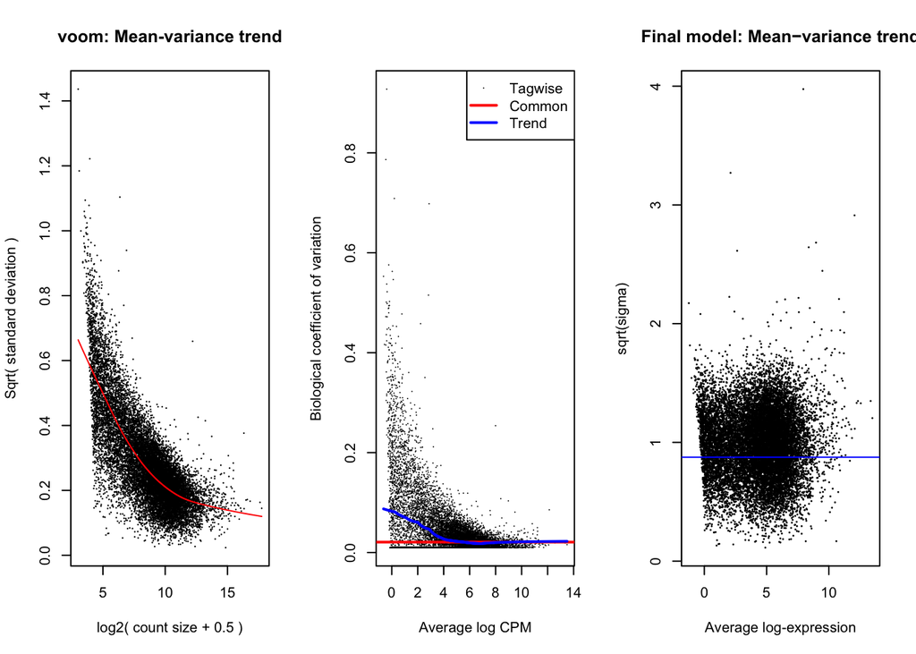

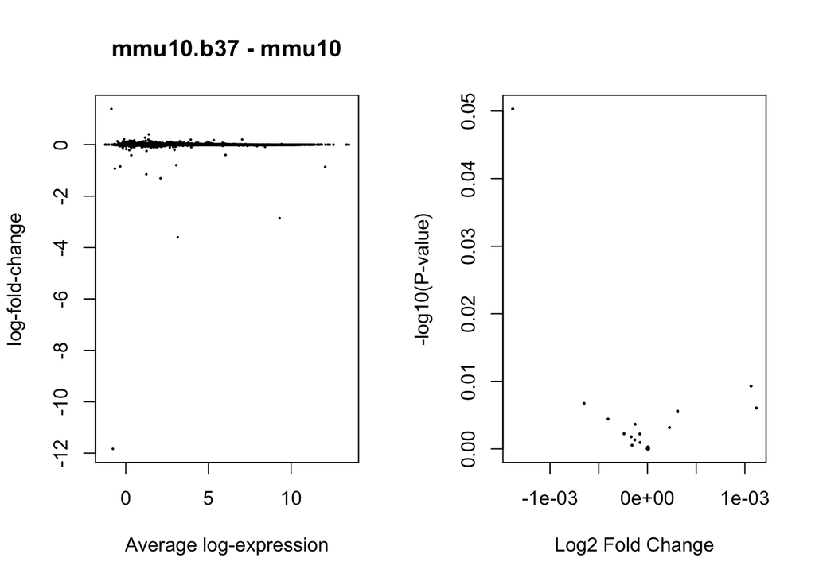

```r
for(i in 1:ncol(cont)){
  print(colnames(cont)[i])
  print(topTable.annotated.DE(DE.data$efit,spec="mouse",coef=i))
}
```

```
## [1] "mmu10.b37 - b37.mmu10"
```

```
## Empty data.table (0 rows) of 2 cols: rn,x
## [1] "mmu10.b37 - mmu10"
```

```
##               ENSEMBL      logFC    AveExpr         t      P.Value
## 1: ENSMUSG00000035202  -2.856665  9.3055294 -50.53184 1.077481e-11
## 2: ENSMUSG00000086324  -3.603262  3.1417838 -38.53270 1.030812e-10
## 3: ENSMUSG00000098973 -11.834279 -0.7814639 -18.50311 4.437185e-08
##       adj.P.Val         B direction  ENTREZID  SYMBOL
## 1: 1.630983e-07 15.196264  down.reg    102436   Lars2
## 2: 7.801702e-07  3.856072  down.reg      <NA>    <NA>
## 3: 2.238856e-04 -1.781161  down.reg 102465959 Mir6236
##                                 GENENAME
## 1: leucyl-tRNA synthetase, mitochondrial
## 2:                                  <NA>
## 3:                         microRNA 6236
```

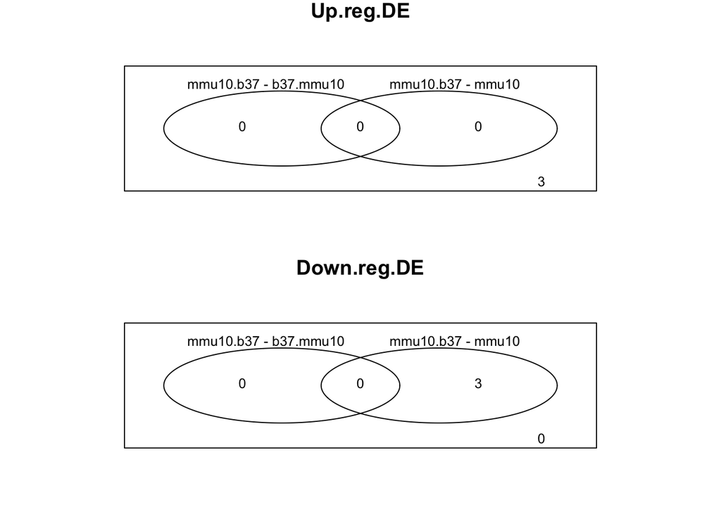

```r
vennDiagram.paired(decideTest.annotated.DE(DE.data$efit,spec="mouse")[,2:(ncol(cont)+1)])
```